# Exploratory Survival Graphs from d01 Procalcitonin Project and the CHF,ESLD ,GLOBAL, renal failure project

## Exploratory Survival Graphs from d01 Procalcitonin Project and the CHF,ESLD ,GLOBAL, renal failure project

```r
anonMASTER <- read.csv("~/Desktop/Procalcitonin Day 01 Priject/anonMASTER.csv")

library(ggplot2)
library(caret)
library(dplyr)
```

## Exploratory Graphs

```r
data <- anonMASTER
data <- tbl_df(data)
qplot(LACTATE.d01,Survival,data=data, colour=Survival)
anonMASTER <- mutate(anonMASTER, devakirifle2=(d2max_cr/CR.d01)>=2)
data <- anonMASTER
```

```r
qplot(LACTATE.d01,Survival,data=data, colour=ESLD, geom=c("point","smooth"), method=lm)
```

```r
qplot(log(PROCALCITONIN.d01),Survival,data=data,colour=ESLD, geom=c("point","smooth"), method=lm)
```

## ** ESLD AKI models **

Below we will create a data set esldnowesrd which contains the patients that have a cirrhosis code and do not have a esrd.ckd 5 code.

```r
## define the esld subset and exclude the chronic dialysis patients##
anonmaster4 <- read.csv("~/Desktop/Procalcitonin Day 01 Priject/anonmaster4.csv")
esld <- subset(anonmaster4, ESLD=="ESLD")

esldnonesrd <- subset(esld, ESRD_CKD.5="non ESRD.CKD5")

## glm for predicing the risk of RIFLE stage1  AKI in the encounter in this subset##
g <- glm(devaki~WBC.d01 + log(PROCALCITONIN.d01) + CR.d01 +DM2 + Htn + PLATELETS.d01+LACTATE.d01, data=esldnonesrd, family=binomial(link=logit))
```

## Summary of the GLM for developing renal injury of >= RIFLE stage 1 in hospitalised ESLD patients who do not have prexisting stage 5 ESRD.

```r
summary(g)
```

```
##
## Call:
## glm(formula = devaki ~ WBC.d01 + log(PROCALCITONIN.d01) + CR.d01 +
##     DM2 + Htn + PLATELETS.d01 + LACTATE.d01, family = binomial(link = logit),
##     data = esldnonesrd)
##
## Deviance Residuals:
##    Min      1Q  Median      3Q     Max
## -1.217  -0.461  -0.303  -0.175   3.157
##
## Coefficients:
##                        Estimate Std. Error z value Pr(>|z|)
## (Intercept)            -0.01684    1.96581   -0.01    0.993
## WBC.d01                -0.01034    0.07423   -0.14    0.889
## log(PROCALCITONIN.d01)  0.62057    0.37404    1.66    0.097 .
## CR.d01                  0.03011    0.29135    0.10    0.918
## DM2no DM2              -1.90340    1.32789   -1.43    0.152
## Htnno htn              -1.83503    1.28125   -1.43    0.152
## PLATELETS.d01          -0.00512    0.00682   -0.75    0.453
## LACTATE.d01             0.15554    0.15074    1.03    0.302
## ---
## Signif. codes:  0 '***' 0.001 '**' 0.01 '*' 0.05 '.' 0.1 ' ' 1
##
## (Dispersion parameter for binomial family taken to be 1)
##
##     Null deviance: 37.907  on 54  degrees of freedom
## Residual deviance: 30.211  on 47  degrees of freedom
##   (13 observations deleted due to missingness)
## AIC: 46.21
##
## Number of Fisher Scoring iterations: 6
```

```r
## define the esld subset and exclude the chronic dialysis patients##
anonmaster4 <- read.csv("~/Desktop/Procalcitonin Day 01 Priject/anonmaster4.csv")
esld <- subset(anonmaster4, ESLD=="ESLD")

esldnonesrd <- subset(esld, ESRD_CKD.5="non ESRD.CKD5")
## glm for predicing the risk of starting rrt in the encounter in this subset##
rrtbin <- glm(rrtbin ~ WBC.d01 + log(PROCALCITONIN.d01) + CR.d01 +DM2 + Htn + PLATELETS.d01 +LACTATE.d01, data=esldnonesrd, family=binomial(link=logit))

rifle1 <- glm(devaki ~ WBC.d01 + log(PROCALCITONIN.d01) + CR.d01 +DM2 + Htn + PLATELETS.d01 +LACTATE.d01, data=esldnonesrd, family=binomial(link=logit))
```

** Not enough data to look at patients in the rifle2 and rifle 3 categories in ESLD patients. Algorithms dont converge for rifle 2 and rifle 3 patients. The RRT data is shown below.**

```r
rifle2 <- glm(devakirifle2 ~ WBC.d01 + log(PROCALCITONIN.d01) + CR.d01 +DM2 + Htn + PLATELETS.d01 +LACTATE.d01 +AGE, data=esldnonesrd, family=binomial(link=logit))
rifle3  <- glm(devakirifle3 ~ WBC.d01 + log(PROCALCITONIN.d01) + CR.d01 +DM2 + Htn + PLATELETS.d01 +LACTATE.d01 +AGE, data=esldnonesrd, family=binomial(link=logit))
## GLM for the intiation of RRT in ESLD patients in hospitalised patients. (Not with preexisting ESRD)
summary(rrtbin)
```

```
##
## Call:
## glm(formula = rrtbin ~ WBC.d01 + log(PROCALCITONIN.d01) + CR.d01 +
##     DM2 + Htn + PLATELETS.d01 + LACTATE.d01, family = binomial(link = logit),
##     data = esldnonesrd)
##
## Deviance Residuals:
##    Min      1Q  Median      3Q     Max
## -1.694  -0.557  -0.244   0.483   2.386
##
## Coefficients:
##                        Estimate Std. Error z value Pr(>|z|)
## (Intercept)            -5.56520    2.15312   -2.58   0.0097 **
## WBC.d01                 0.16787    0.07291    2.30   0.0213 *
## log(PROCALCITONIN.d01)  0.46430    0.28357    1.64   0.1016
## CR.d01                  1.42445    0.43306    3.29   0.0010 **
## DM2no DM2              -0.55779    0.93853   -0.59   0.5523
## Htnno htn              -0.12755    0.97284   -0.13   0.8957
## PLATELETS.d01          -0.00417    0.00383   -1.09   0.2763
## LACTATE.d01             0.07702    0.14385    0.54   0.5923
## ---
## Signif. codes:  0 '***' 0.001 '**' 0.01 '*' 0.05 '.' 0.1 ' ' 1
##
## (Dispersion parameter for binomial family taken to be 1)
##
##     Null deviance: 72.103  on 54  degrees of freedom
## Residual deviance: 40.918  on 47  degrees of freedom
##   (13 observations deleted due to missingness)
## AIC: 56.92
##
## Number of Fisher Scoring iterations: 6
```

## CHF and RRT models

```r
anonmaster4 <- read.csv("~/Desktop/Procalcitonin Day 01 Priject/anonmaster4.csv")
data <- anonmaster4

chf <- subset(data, CHF=="CHF")
chfnoesrd<- subset(chf, ESRD_CKD5=="non ESRD.CKD5" )


glm.chf.rrt <- glm(rrtbin~log(PROCALCITONIN.d01)+ WBC.d01 +CR.d01 + ALB.d01+DM2 +min_sodium+AGE+Htn+PHtn,data=chfnoesrd, family=binomial)
summary(glm.chf.rrt)
```

```
##
## Call:
## glm(formula = rrtbin ~ log(PROCALCITONIN.d01) + WBC.d01 + CR.d01 +
##     ALB.d01 + DM2 + min_sodium + AGE + Htn + PHtn, family = binomial,
##     data = chfnoesrd)
##
## Deviance Residuals:
##    Min      1Q  Median      3Q     Max
## -1.193  -0.347  -0.208  -0.132   2.640
##
## Coefficients:
##                        Estimate Std. Error z value Pr(>|z|)
## (Intercept)             7.38851   11.29898    0.65    0.513
## log(PROCALCITONIN.d01)  0.49210    0.22388    2.20    0.028 *
## WBC.d01                -0.02114    0.04776   -0.44    0.658
## CR.d01                  0.44947    0.22016    2.04    0.041 *
## ALB.d01                 0.06286    0.62419    0.10    0.920
## DM2no DM2              -0.13255    0.78225   -0.17    0.865
## min_sodium             -0.08090    0.08729   -0.93    0.354
## AGE                    -0.01144    0.02326   -0.49    0.623
## Htnno htn              -0.00316    0.80338    0.00    0.997
## PHtnPHtn                1.71050    0.88157    1.94    0.052 .
## ---
## Signif. codes:  0 '***' 0.001 '**' 0.01 '*' 0.05 '.' 0.1 ' ' 1
##
## (Dispersion parameter for binomial family taken to be 1)
##
##     Null deviance: 68.336  on 151  degrees of freedom
## Residual deviance: 53.232  on 142  degrees of freedom
##   (55 observations deleted due to missingness)
## AIC: 73.23
##
## Number of Fisher Scoring iterations: 7
```

```r
glm.chf.rrt.lact <- glm(rrtbin~log(PROCALCITONIN.d01)+LACTATE.d01+ WBC.d01 +CR.d01 + PHtn + ALB.d01+DM2 +min_sodium +AGE + min_hb+Htn,data=chfnoesrd, family=binomial)
summary(glm.chf.rrt.lact)
```

```
##
## Call:
## glm(formula = rrtbin ~ log(PROCALCITONIN.d01) + LACTATE.d01 +
##     WBC.d01 + CR.d01 + PHtn + ALB.d01 + DM2 + min_sodium + AGE +
##     min_hb + Htn, family = binomial, data = chfnoesrd)
##
## Deviance Residuals:
##    Min      1Q  Median      3Q     Max
## -1.363  -0.360  -0.207  -0.106   2.452
##
## Coefficients:
##                        Estimate Std. Error z value Pr(>|z|)
## (Intercept)              5.2107    13.6340    0.38    0.702
## log(PROCALCITONIN.d01)   0.4984     0.2954    1.69    0.092 .
## LACTATE.d01              0.1259     0.1399    0.90    0.368
## WBC.d01                 -0.0344     0.0660   -0.52    0.602
## CR.d01                   0.4392     0.2161    2.03    0.042 *
## PHtnPHtn                 1.7955     1.1051    1.62    0.104
## ALB.d01                 -0.4277     0.7502   -0.57    0.569
## DM2no DM2               -0.4374     0.9930   -0.44    0.660
## min_sodium              -0.0691     0.1085   -0.64    0.524
## AGE                     -0.0288     0.0283   -1.01    0.310
## min_hb                   0.2664     0.2150    1.24    0.215
## Htnno htn                0.5502     0.9246    0.60    0.552
## ---
## Signif. codes:  0 '***' 0.001 '**' 0.01 '*' 0.05 '.' 0.1 ' ' 1
##
## (Dispersion parameter for binomial family taken to be 1)
##
##     Null deviance: 55.417  on 97  degrees of freedom
## Residual deviance: 39.823  on 86  degrees of freedom
##   (109 observations deleted due to missingness)
## AIC: 63.82
##
## Number of Fisher Scoring iterations: 7
```

```r
glm.chf.rrt.lact2 <- glm(rrtbin~LACTATE.d01+CR.d01,data=chfnoesrd, family=binomial)
summary(glm.chf.rrt.lact2)
```

```
##
## Call:
## glm(formula = rrtbin ~ LACTATE.d01 + CR.d01, family = binomial,
##     data = chfnoesrd)
##
## Deviance Residuals:
##    Min      1Q  Median      3Q     Max
## -1.077  -0.389  -0.322  -0.272   2.626
##
## Coefficients:
##             Estimate Std. Error z value Pr(>|z|)
## (Intercept)  -4.2523     0.8172   -5.20    2e-07 ***
## LACTATE.d01   0.1674     0.0982    1.70    0.088 .
## CR.d01        0.6987     0.3240    2.16    0.031 *
## ---
## Signif. codes:  0 '***' 0.001 '**' 0.01 '*' 0.05 '.' 0.1 ' ' 1
##
## (Dispersion parameter for binomial family taken to be 1)
##
##     Null deviance: 74.286  on 123  degrees of freedom
## Residual deviance: 62.028  on 121  degrees of freedom
##   (83 observations deleted due to missingness)
## AIC: 68.03
##
## Number of Fisher Scoring iterations: 6
```

```r
glm.chf.rrt.lact3 <- glm(rrtbin~log(PROCALCITONIN.d01)+CR.d01,data=chfnoesrd, family=binomial)
summary(glm.chf.rrt.lact3)
```

```
##
## Call:
## glm(formula = rrtbin ~ log(PROCALCITONIN.d01) + CR.d01, family = binomial,
##     data = chfnoesrd)
##
## Deviance Residuals:
##    Min      1Q  Median      3Q     Max
## -0.913  -0.346  -0.234  -0.175   2.835
##
## Coefficients:
##                        Estimate Std. Error z value Pr(>|z|)
## (Intercept)              -4.221      0.714   -5.91  3.4e-09 ***
## log(PROCALCITONIN.d01)    0.359      0.150    2.38    0.017 *
## CR.d01                    0.685      0.299    2.29    0.022 *
## ---
## Signif. codes:  0 '***' 0.001 '**' 0.01 '*' 0.05 '.' 0.1 ' ' 1
##
## (Dispersion parameter for binomial family taken to be 1)
##
##     Null deviance: 91.518  on 205  degrees of freedom
## Residual deviance: 74.787  on 203  degrees of freedom
##   (1 observation deleted due to missingness)
## AIC: 80.79
##
## Number of Fisher Scoring iterations: 6
```

```r
qplot( log(PROCALCITONIN.d01),CR.d01-d2max_cr,data=chfnoesrd, colour=rrtbin)
```

[figure not shown]

## CHF AKI RIFLE Stage I models

```r
glm.chf.aki <- glm(devaki~log(PROCALCITONIN.d01)+WBC.d01+DM2+CR.d01+gender+ALB.d01+ESLD+PHtn+Htn,data=chfnoesrd, family=binomial(link=logit))
summary(glm.chf.aki)
```

```
##
## Call:
## glm(formula = devaki ~ log(PROCALCITONIN.d01) + WBC.d01 + DM2 +
##     CR.d01 + gender + ALB.d01 + ESLD + PHtn + Htn, family = binomial(link = logit),
##     data = chfnoesrd)
##
## Deviance Residuals:
##    Min      1Q  Median      3Q     Max
## -0.973  -0.416  -0.324  -0.222   2.628
##
## Coefficients:
##                        Estimate Std. Error z value Pr(>|z|)
## (Intercept)             -2.8696     2.3735   -1.21    0.227
## log(PROCALCITONIN.d01)   0.3525     0.1566    2.25    0.024 *
## WBC.d01                 -0.0588     0.0473   -1.24    0.214
## DM2no DM2               -0.4732     0.6253   -0.76    0.449
## CR.d01                  -0.3810     0.4716   -0.81    0.419
## genderM                 -0.2416     0.6751   -0.36    0.720
## ALB.d01                  0.6485     0.5113    1.27    0.205
## ESLDnon ESLD            -0.1257     1.1322   -0.11    0.912
## PHtnPHtn                -0.0123     0.7962   -0.02    0.988
## Htnno htn               -0.1574     0.6281   -0.25    0.802
## ---
## Signif. codes:  0 '***' 0.001 '**' 0.01 '*' 0.05 '.' 0.1 ' ' 1
##
## (Dispersion parameter for binomial family taken to be 1)
##
##     Null deviance: 91.822  on 169  degrees of freedom
## Residual deviance: 82.634  on 160  degrees of freedom
##   (37 observations deleted due to missingness)
## AIC: 102.6
##
## Number of Fisher Scoring iterations: 6
```

```r
glm.chf.aki.lact <- glm(devaki~log(PROCALCITONIN.d01)+LACTATE.d01+WBC.d01+DM2+PHtn+min_sodium+CR.d01+gender+ALB.d01,data=chfnoesrd, family=binomial(link=logit))

summary(glm.chf.aki.lact)
```

```
##
## Call:
## glm(formula = devaki ~ log(PROCALCITONIN.d01) + LACTATE.d01 +
##     WBC.d01 + DM2 + PHtn + min_sodium + CR.d01 + gender + ALB.d01,
##     family = binomial(link = logit), data = chfnoesrd)
##
## Deviance Residuals:
##    Min      1Q  Median      3Q     Max
## -1.280  -0.399  -0.201  -0.117   2.779
##
## Coefficients:
##                        Estimate Std. Error z value Pr(>|z|)
## (Intercept)              8.3201    13.3358    0.62    0.533
## log(PROCALCITONIN.d01)   0.5900     0.2810    2.10    0.036 *
## LACTATE.d01             -0.0939     0.1854   -0.51    0.613
## WBC.d01                 -0.0371     0.0643   -0.58    0.564
## DM2no DM2               -1.0748     1.0157   -1.06    0.290
## PHtnPHtn                 0.8141     1.3454    0.61    0.545
## min_sodium              -0.0899     0.1038   -0.87    0.387
## CR.d01                  -1.1553     0.8197   -1.41    0.159
## genderM                  0.2784     1.0809    0.26    0.797
## ALB.d01                  0.9259     0.8083    1.15    0.252
## ---
## Signif. codes:  0 '***' 0.001 '**' 0.01 '*' 0.05 '.' 0.1 ' ' 1
##
## (Dispersion parameter for binomial family taken to be 1)
##
##     Null deviance: 55.417  on 97  degrees of freedom
## Residual deviance: 41.894  on 88  degrees of freedom
##   (109 observations deleted due to missingness)
## AIC: 61.89
##
## Number of Fisher Scoring iterations: 7
```

## Stage 1 RIFLE AKI in CHF All Subset Regression

*We will generate all subset regression with the LEAPS package for looking at risk factors for developing AKI in patient with a history of CHF in the dataset. We are using the devaki variable as an outcome (1.5X rise in Cr, over admission day Creatinine)((d2max_cr/cr.d01 > 1.5)*

```r
library(MASS)
library(leaps)
attach(chfnoesrd)
```

```r
leaps <- regsubsets(devaki~log(PROCALCITONIN.d01)+LACTATE.d01+WBC.d01+DM2+CR.d01+gender+ALB.d01+ESLD+PHtn+Htn,data=chfnoesrd, nbest=10)

plot(leaps)
```

[figure not shown]

## Stage 1 RIFLE AKI in CHF Odds ratio table

*We will generate an odds ratio table for looking at risk factors for developing AKI in patient with a history of CHF in the dataset. We are using the devaki variable which essentially corresponds to a rifle stage 1 definition of renal failure (d2max_cr/cr.d01 > 1.5)*

```r
aki <- glm(formula = devaki ~ log(PROCALCITONIN.d01) + LACTATE.d01 +
WBC.d01 + DM2 + CR.d01 + gender + ALB.d01 + ESLD + PHtn,
family = binomial(link = logit), data = chfnoesrd)
int <- exp(confint(aki))
odds <- exp(coef(aki))
akioddstable <- cbind(odds,int)
akioddstable
```

```
##                          odds    2.5 %  97.5 %
## (Intercept)            0.6846 0.001213 264.647
## log(PROCALCITONIN.d01) 2.0033 1.268276   3.617
## LACTATE.d01            0.9544 0.638179   1.265
## WBC.d01                0.9252 0.807300   1.027
## DM2no DM2              0.2911 0.038014   1.643
## CR.d01                 0.4175 0.092484   1.153
## genderM                0.8931 0.129960   6.709
## ALB.d01                1.3277 0.405007   5.002
## ESLDnon ESLD           0.4399 0.044187  10.652
## PHtnPHtn               2.1494 0.157377  26.938
```

## CHF AKI RIFLE Stage 2 (d2maxcr/Cr.d01 >2)

```r
anonMASTER <- mutate(anonMASTER, devakirifle2=(d2max_cr/CR.d01)>=2)
data <- anonMASTER
chf <- subset(data, CHF=="CHF")
chfnoesrd<- subset(chf, ESRD_CKD5=="non ESRD.CKD5" )
glm.chf.aki.rifle2 <- glm(devakirifle2~log(PROCALCITONIN.d01)+LACTATE.d01+ WBC.d01+DM2+CR.d01+gender+ALB.d01+ELSD+AGE+PHtn+Htn,data=chfnoesrd, family=binomial(link=logit))
```

[output not shown]

```r
summary(glm.chf.aki.rifle2)
```

```
## Error: object 'glm.chf.aki.rifle2' not found
```

```r
glmrifle2 <- glm.chf.aki.rifle2
```

```
## Error: object 'glm.chf.aki.rifle2' not found
```

```r
int <- exp(confint(glm.chf.aki.rifle2))
```

```
## Error: object 'glm.chf.aki.rifle2' not found
```

```r
odds <- exp(coef(glm.chf.aki.rifle2))
```

```
## Error: object 'glm.chf.aki.rifle2' not found
```

```r
akioddstable <- cbind(odds,int)
akioddstable
```

[output not shown]

*All subsets regression fo RIFLE2 renal failure in CHF*

```r
library(MASS)
library(leaps)
attach(chfnoesrd)
```

```r
leaps <- regsubsets(devakirifle2~log(PROCALCITONIN.d01)+LACTATE.d01+WBC.d01+DM2+CR.d01+gender+ALB.d01+ESLD+PHtn+Htn,data=chfnoesrd, nbest=10)

plot(leaps)
```

[figure not shown]

## CHF and RIFLE 3 AKI Models

*We are generating glm models on the outcome of RIFLE 3 Renal failure which includes a Creatinine rise of >3X and or RRT.*

```r
library(dplyr)
anonMASTER3 <- mutate(anonMASTER, devakirifle3=(d2max_cr/CR.d01)>=3)
anonmaster3 <- mutate(anonMASTER3,rifle4 = (CR.d01 >=4 & ((d2max_cr-CR.d01)>=0.5)))
anonmaster4 <- mutate(anonmaster3, rifle3 = (devakirifle3=="TRUE" | rrtbin =="TRUE" | rifle4 == "TRUE"))


data <- anonmaster4

chf <- subset(data, CHF=="CHF")

chfnoesrd<- subset(chf, ESRD_CKD5=="non ESRD.CKD5" )
## glm for rifle3
chfrifle3 <- glm(rifle3~log(PROCALCITONIN.d01)+LACTATE.d01+ WBC.d01+DM2+CR.d01+gender+ALB.d01+PHtn+Htn+AGE+min_sodium+min_hb,data=chfnoesrd, family=binomial(link=logit))

summary(chfrifle3)
```

```
##
## Call:
## glm(formula = rifle3 ~ log(PROCALCITONIN.d01) + LACTATE.d01 +
##     WBC.d01 + DM2 + CR.d01 + gender + ALB.d01 + PHtn + Htn +
##     AGE + min_sodium + min_hb, family = binomial(link = logit),
##     data = chfnoesrd)
##
## Deviance Residuals:
##     Min       1Q   Median       3Q      Max
## -1.6303  -0.4136  -0.2070  -0.0616   2.5345
##
## Coefficients:
##                        Estimate Std. Error z value Pr(>|z|)
## (Intercept)             15.5616    12.8928    1.21    0.227
## log(PROCALCITONIN.d01)   0.7174     0.2961    2.42    0.015 *
## LACTATE.d01              0.0596     0.1215    0.49    0.624
## WBC.d01                 -0.0263     0.0507   -0.52    0.603
## DM2no DM2                0.2967     0.8841    0.34    0.737
## CR.d01                   0.7798     0.3937    1.98    0.048 *
## genderM                  1.2935     1.1555    1.12    0.263
## ALB.d01                  0.1962     0.7720    0.25    0.799
## PHtnPHtn                 2.4523     1.2919    1.90    0.058 .
## Htnno htn               -1.3225     0.9541   -1.39    0.166
## AGE                     -0.0189     0.0241   -0.78    0.434
## min_sodium              -0.1589     0.1028   -1.55    0.122
## min_hb                   0.0995     0.1773    0.56    0.575
## ---
## Signif. codes:  0 '***' 0.001 '**' 0.01 '*' 0.05 '.' 0.1 ' ' 1
##
## (Dispersion parameter for binomial family taken to be 1)
##
##     Null deviance: 72.868  on 97  degrees of freedom
## Residual deviance: 46.260  on 85  degrees of freedom
##   (109 observations deleted due to missingness)
## AIC: 72.26
##
## Number of Fisher Scoring iterations: 7
```

```r
##odds ratio table
int <- exp(confint(chfrifle3))
odds <- exp(coef(chfrifle3))
akioddstable <- cbind(odds,int)
akioddstable
```

```
##                             odds     2.5 %    97.5 %
## (Intercept)            5.732e+06 0.0002436 3.568e+18
## log(PROCALCITONIN.d01) 2.049e+00 1.2106347 3.961e+00
## LACTATE.d01            1.061e+00 0.8226065 1.348e+00
## WBC.d01                9.740e-01 0.8660107 1.061e+00
## DM2no DM2              1.345e+00 0.2237074 7.997e+00
## CR.d01                 2.181e+00 1.2870441 5.321e+00
## genderM                3.645e+00 0.4259920 4.453e+01
## ALB.d01                1.217e+00 0.2722270 6.148e+00
## PHtnPHtn               1.162e+01 1.0192807 1.885e+02
## Htnno htn              2.665e-01 0.0333966 1.561e+00
## AGE                    9.813e-01 0.9340495 1.029e+00
## min_sodium             8.531e-01 0.6811371 1.019e+00
## min_hb                 1.105e+00 0.7801172 1.602e+00
```

```r
library(glmulti)
chfrifle3 <- glm(rifle3~log(PROCALCITONIN.d01)+LACTATE.d01+ WBC.d01+DM2+CR.d01+gender+ALB.d01+Htn+min_sodium+min_hb+AGE,data=chfnoesrd, family=binomial(link=logit), na.action=na.exclude)

multi.chf.model <- glmulti(chfrifle3, # use the model with built as a starting point
                      level = 1,  #  just look at main effects
                      crit="aicc") # use AICc because it works better than AIC for small sample sizes)
```

```
## Initialization...
## TASK: Exhaustive screening of candidate set.
## Fitting...
##
## After 50 models:
## Best model: rifle3~1+log(PROCALCITONIN.d01)+CR.d01+min_sodium
## Crit= 24.4634293420555
## Mean crit= 57.2004072912646
```

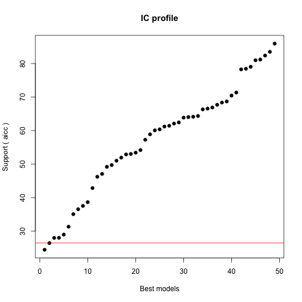

```
##
## After 100 models:
## Best model: rifle3~1+log(PROCALCITONIN.d01)+CR.d01+min_sodium
## Crit= 24.4634293420555
## Mean crit= 53.5872902402722
```

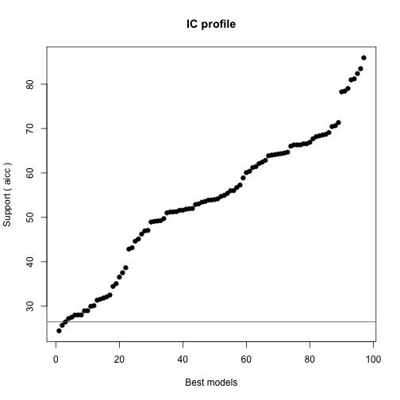

```
##
## After 150 models:
## Best model: rifle3~1+log(PROCALCITONIN.d01)+CR.d01+min_sodium
## Crit= 24.4634293420555
## Mean crit= 46.0746342885933
```

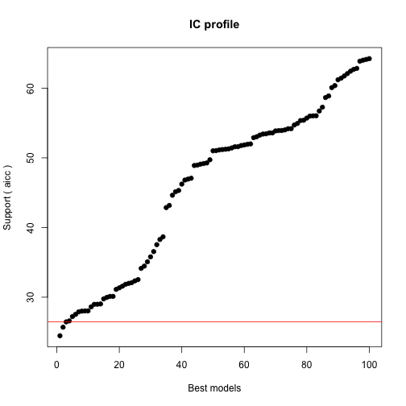

```
##
## After 200 models:
## Best model: rifle3~1+log(PROCALCITONIN.d01)+CR.d01+min_sodium
## Crit= 24.4634293420555
## Mean crit= 41.7770613455725
```

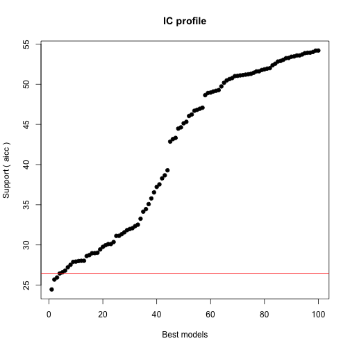

```
##
## After 250 models:
## Best model: rifle3~1+log(PROCALCITONIN.d01)+CR.d01+min_sodium
## Crit= 24.4634293420555
## Mean crit= 38.8626514453523
```

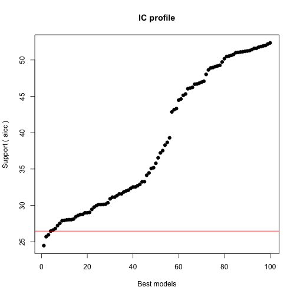

```
##
## After 300 models:
## Best model: rifle3~1+log(PROCALCITONIN.d01)+CR.d01+min_sodium
## Crit= 24.4634293420555
## Mean crit= 37.0102603486173
```

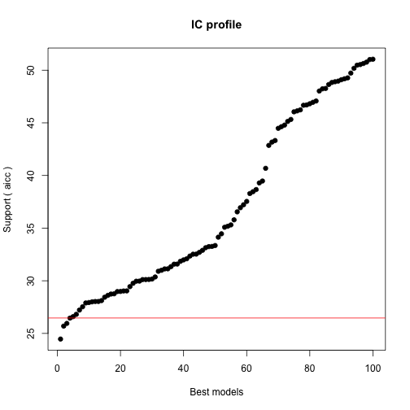

```
##
## After 350 models:
## Best model: rifle3~1+log(PROCALCITONIN.d01)+CR.d01+min_sodium
## Crit= 24.4634293420555
## Mean crit= 34.6123116115685
```

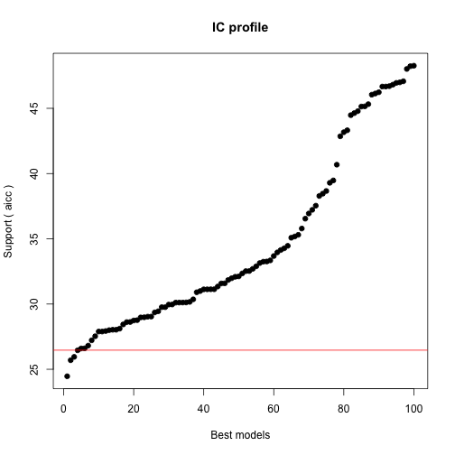

```
##
## After 400 models:
## Best model: rifle3~1+log(PROCALCITONIN.d01)+CR.d01+min_sodium
## Crit= 24.4634293420555
## Mean crit= 32.87921495582
```

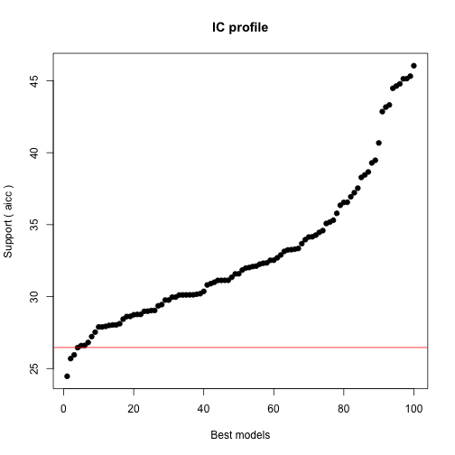

```
##
## After 450 models:
## Best model: rifle3~1+log(PROCALCITONIN.d01)+CR.d01+min_sodium
## Crit= 24.4634293420555
## Mean crit= 31.8877047454736
```

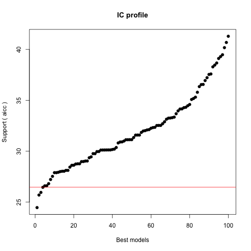

```
##
## After 500 models:
## Best model: rifle3~1+log(PROCALCITONIN.d01)+CR.d01+min_sodium
## Crit= 24.4634293420555
## Mean crit= 31.1937396778474
```

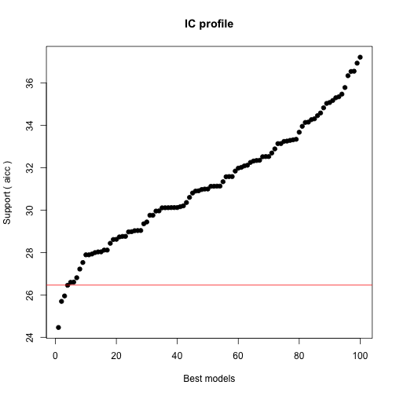

```
##
## After 550 models:
## Best model: rifle3~1+log(PROCALCITONIN.d01)+CR.d01+min_sodium
## Crit= 24.4634293420555
## Mean crit= 30.8765081821073
```

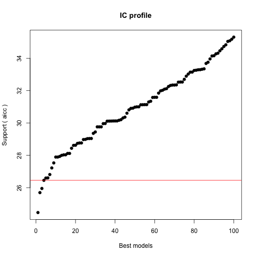

```
##
## After 600 models:
## Best model: rifle3~1+log(PROCALCITONIN.d01)+CR.d01+min_sodium
## Crit= 24.4634293420555
## Mean crit= 30.4869518169527
```

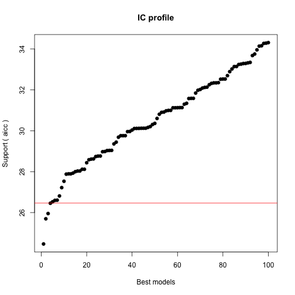

```
##
## After 650 models:
## Best model: rifle3~1+log(PROCALCITONIN.d01)+CR.d01+min_sodium
## Crit= 24.4634293420555
## Mean crit= 30.2407870998398
```

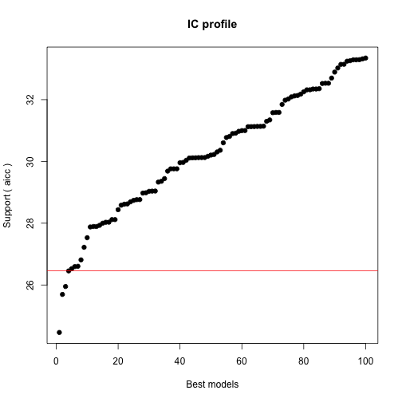

```
##
## After 700 models:
## Best model: rifle3~1+log(PROCALCITONIN.d01)+CR.d01+min_sodium
## Crit= 24.4634293420555
## Mean crit= 30.1658700428566
```

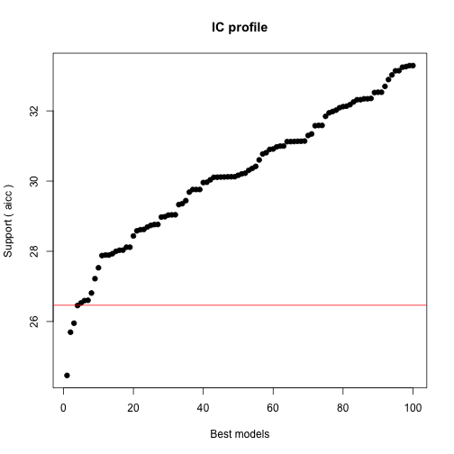

```
##
## After 750 models:
## Best model: rifle3~1+log(PROCALCITONIN.d01)+CR.d01+min_sodium
## Crit= 24.4634293420555
## Mean crit= 29.9505534885163
```

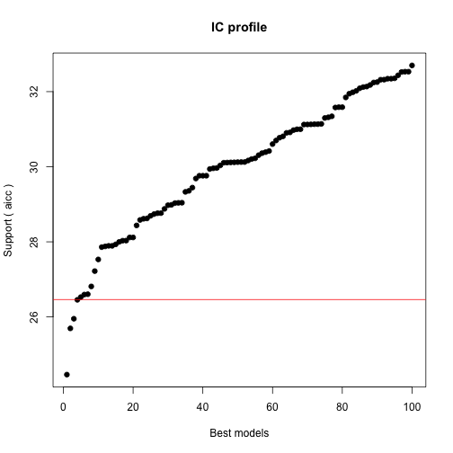

```
##
## After 800 models:
## Best model: rifle3~1+log(PROCALCITONIN.d01)+CR.d01+min_sodium
## Crit= 24.4634293420555
## Mean crit= 29.8892704631747
```

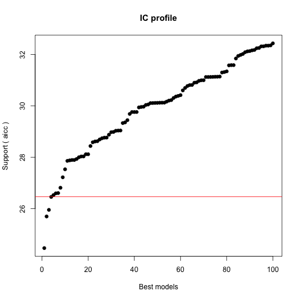

```
##
## After 850 models:
## Best model: rifle3~1+log(PROCALCITONIN.d01)+CR.d01+min_sodium
## Crit= 24.4634293420555
## Mean crit= 29.8283238375579
```

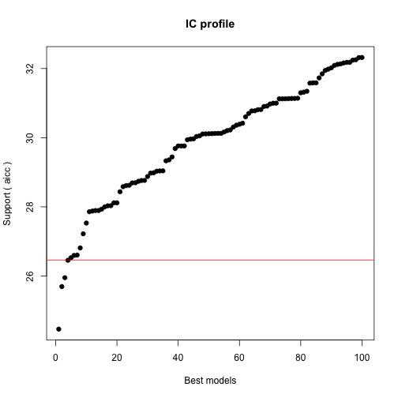

```
##
## After 900 models:
## Best model: rifle3~1+log(PROCALCITONIN.d01)+CR.d01+min_sodium
## Crit= 24.4634293420555
## Mean crit= 29.7948807281551
```

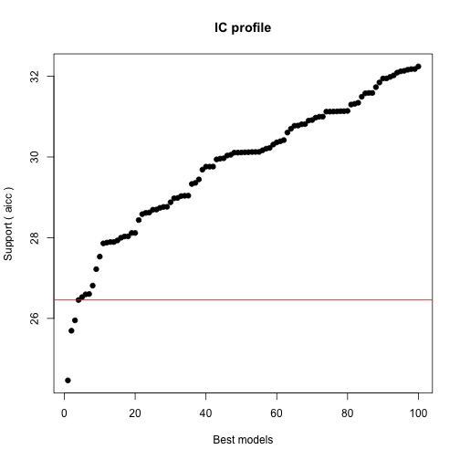

```
##
## After 950 models:
## Best model: rifle3~1+log(PROCALCITONIN.d01)+CR.d01+min_sodium
## Crit= 24.4634293420555
## Mean crit= 29.7813204415808
```

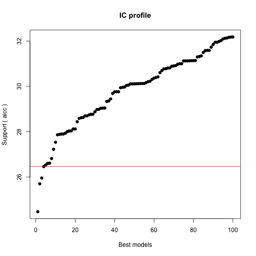

```
##
## After 1000 models:
## Best model: rifle3~1+log(PROCALCITONIN.d01)+CR.d01+min_sodium
## Crit= 24.4634293420555
## Mean crit= 29.7496512580229
```

[output not shown]

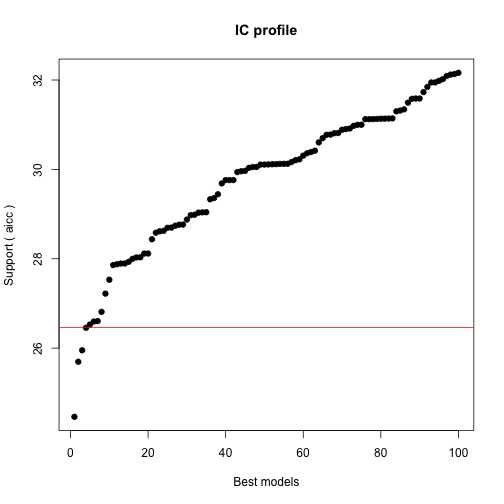

```
##
## After 1100 models:
## Best model: rifle3~1+log(PROCALCITONIN.d01)+CR.d01+min_sodium
## Crit= 24.4634293420555
## Mean crit= 29.7187210059059
```

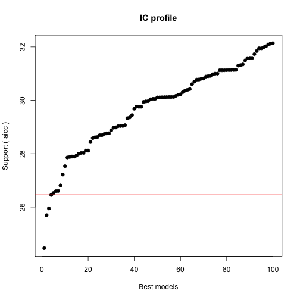

```
##
## After 1150 models:
## Best model: rifle3~1+log(PROCALCITONIN.d01)+CR.d01+min_sodium
## Crit= 24.4634293420555
## Mean crit= 29.3458031015874
```

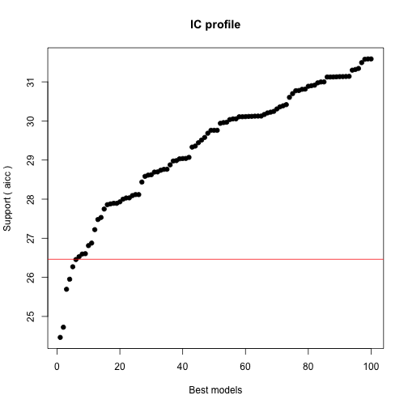

```
##
## After 1200 models:
## Best model: rifle3~1+log(PROCALCITONIN.d01)+CR.d01+min_sodium
## Crit= 24.4634293420555
## Mean crit= 29.1826113136241
```

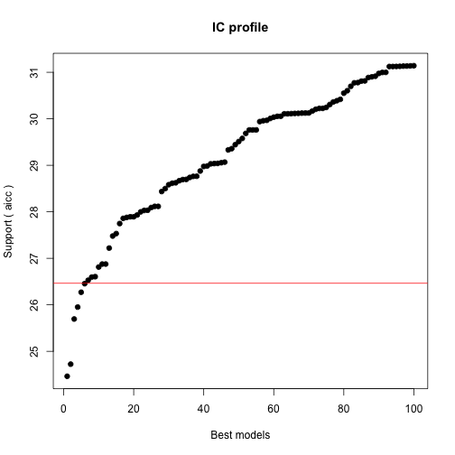

```
##
## After 1250 models:
## Best model: rifle3~1+log(PROCALCITONIN.d01)+CR.d01+min_sodium
## Crit= 24.4634293420555
## Mean crit= 29.0786763215888
```

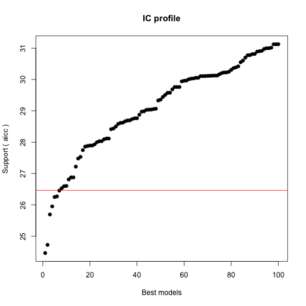

```
##
## After 1300 models:
## Best model: rifle3~1+log(PROCALCITONIN.d01)+CR.d01+min_sodium
## Crit= 24.4634293420555
## Mean crit= 28.9808464272458
```

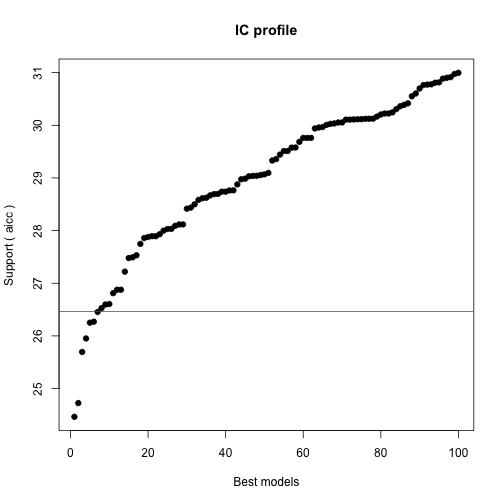

```
##
## After 1350 models:
## Best model: rifle3~1+log(PROCALCITONIN.d01)+CR.d01+min_sodium
## Crit= 24.4634293420555
## Mean crit= 28.9401781976114
```

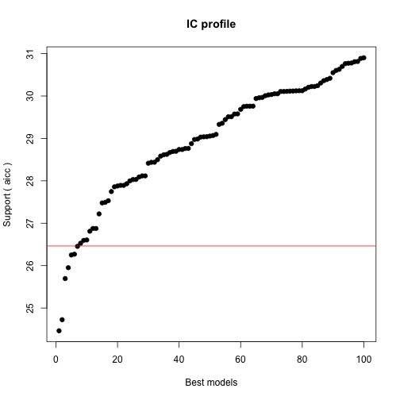

```
##
## After 1400 models:
## Best model: rifle3~1+log(PROCALCITONIN.d01)+CR.d01+min_sodium
## Crit= 24.4634293420555
## Mean crit= 28.8332381885315
```

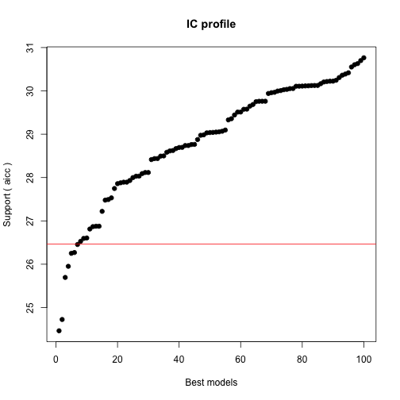

```
##
## After 1450 models:
## Best model: rifle3~1+log(PROCALCITONIN.d01)+CR.d01+min_sodium
## Crit= 24.4634293420555
## Mean crit= 28.8160199085611
```

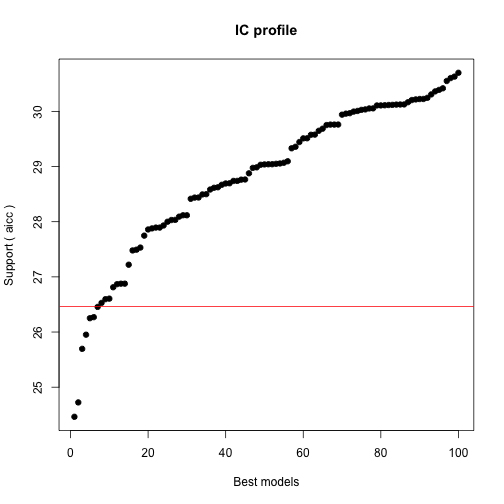

```
##
## After 1500 models:
## Best model: rifle3~1+log(PROCALCITONIN.d01)+CR.d01+min_sodium
## Crit= 24.4634293420555
## Mean crit= 28.7931708171062
```

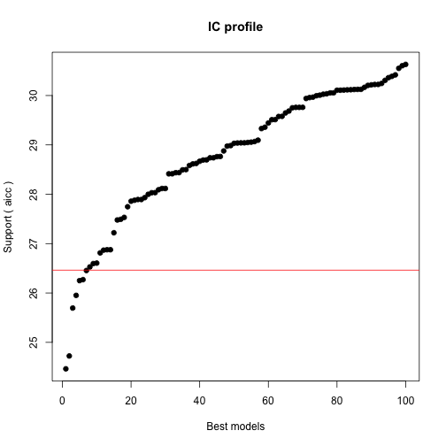